# Module 5 Lecture - Sensation and Perception

Introductory Psychology

Quinton Quagliano, M.S., C.S.P

Department of Psychology

# 1 Overview and Introduction

Agenda

1 Overview and Introduction

2 Sensation versus Perception

3 Waves and Wavelengths

4 Vision

5 Hearing

6 The Other Senses

7 Conclusion

## 1.1 Textbook Learning Objectives

- Distinguish between sensation and perception
- Describe the concepts of absolute threshold and difference threshold
- Discuss the roles attention, motivation, and sensory adaptation play in perception
- Describe important physical features of wave forms
- Show how physical properties of light waves are associated with perceptual experience
- Show how physical properties of sound waves are associated with perceptual experience
- Describe the basic anatomy of the visual system
- Discuss how rods and cones contribute to different aspects of vision
- Describe how monocular and binocular cues are used in the perception of depth
- Describe the basic anatomy and function of the auditory system
- Explain how we encode and perceive pitch
- Discuss how we localize sound
- Describe the basic functions of the chemical senses
- Explain the basic functions of the somatosensory, nociceptive, and thermoceptive sensory systems
- Describe the basic functions of the vestibular, proprioceptive, and kinesthetic sensory systems

## 1.2 Instructor Learning Objectives

- Be able to connect sensation and perception back to concepts in biopsychology, consciousness/sleep, and gestalt psychology
- Explain how the anatomical structure gives rise to functions of perception, much like we did on focusing with brain structures and their respective functions

## 1.3 Introduction

- **Discuss: Close your eyes for a moment and try to be quiet - think about what you hear, smell, feel, taste. Describe some of what you felt here**
- What you just wrote down are stimuli that are being received by your senses (without sight)
- Those senses are taking in the information in our environment and about our body and, put together, give rise to our conscious experience.
- **Discuss: Describe what it means to be conscious, based upon the discussion we had in Module 4**
- Today is all about examining how these different senses work both biologically and psychologically

# 2 Sensation versus Perception

Agenda

1 Overview and Introduction

2 Sensation versus Perception

3 Waves and Wavelengths

4 Vision

5 Hearing

6 The Other Senses

7 Conclusion

## 2.1 Introduction

- Sensation and perception intuitively sound quite similar, but they have some important distinctions in psychological research

## 2.2 Sensation

- **Sensation** occurs via **sensory receptors**, which are a specialized type of neuron.
  - The sensory receptors recieve the actual stimuli, whether that is light, chemical, pressure, etc., and then pass that along to other neurons as an action potential
  - Going from sensory stimuli in its original form to an action potential is called **transduction**
- We have 5 basic senses:
  - Vision
  - Hearing (Audition)
  - Smell (Olfaction)
  - Taste (Gustation)
  - Touch (Somatosensation)
- **Question: What sense is NOT routed through the thalamus**
- A) Smell
- B) Taste
- C) Touch
- D) Hearing
- **Discuss: Review: What lobe of the brain's cortex is most associated with hearing? Where is it located on the human head?**
- We have several other slightly less talked about senses:
  - Vestibular sense (balance)
  - Proprioception and kinesthesia (body position and movement)
  - Nociception (pain)
  - Thermoception (temperature)
- Our senses detect change in the environment, and whether this change is registered in our brain is determined by a sense’s particular **Absolute threshold**
  - The absolute threshold is the amount of energy necessary for a sense to be triggered 50 percent of the time
  - Put another way, a stimulus must reach an absolute threshold for us to become conscious of it 50 percent of the time
  - Example: how dim can a light be where my eyes will still detect light half of the time
- **Discuss: Rewrite that last example regarding the eye and light, but now applied to smell.**
- Not all stimuli is sufficient to rise to the level of consciousness, these stimuli are called **subliminal messages**.
- **Important: Subliminal messages are popularized as having an unconcious and pervasive impact on our behavior, but modern science has largely rejected that notion.**
- Another way of understanding differences in stimulus strength is through **just noticeable difference (jnd) or difference threshold**
  - This model looks at how the same stimulus may be noticeable or unnoticeable in different contexts
  - Example: On my hand, I can feel two pin pricks when they aren’t particularly far apart, but cannot tell that same difference on my kneecap
- **Question: What part of the parietal lobe cortex is set up with different area amounts for sensory input for different parts of the body?**
- A) Broca's area
- B) Wernicke's area
- C) Somatosenroy cortex
- D) Longitudinal fissure

## 2.3 Perception

- Senses are the basic inputs our body takes in and sends as an action potential signal, but **perception** is our actual complex experience and organization of that information
  - Perception comes in two flavors: bottom-up and top-down
  - But, both are constantly active and equally important
- **Bottom-up processing** is taking sensory information and integrating it in our experience
  - It tends to be rapid and outside conscious control
  - Example: somebody drops a large metal water bottle on the floor in the quiet library, everyone reacts to look at it instantaneously out of curiosity or anxitey
- **Top-down processing** is the use of expectations and experiences to recognize stimuli
  - Example: your instructor recognizes subtle signs of possible aggression in a patient as I’ve been trained to closely observe

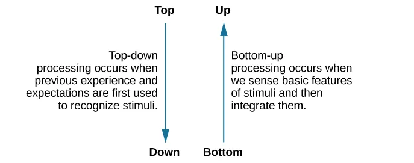

- Top-down and bottom-up processing are hard concepts!
- **Discuss: Try to come up with both an additional example of bottom-up and top-down processing**

## 2.4 Sensations and Perceptions Together

- Recap:
  - Sensation can be though of the basic, biological, physiological process of taking in information
  - Perception is the psychological recognition and understanding of the senses
  - Thus, without sense first, we cannot have perception
- There are many reasons our senses may result in different perceptions
  - Adaptation, attention, motivation (all discussed below)
  - Personality, culture, beliefs, expectations, experiences
- Senses, even when they may initially reach the absolute threshold, may not always rise to perception, due to **sensory adaptation**
  - An example of this would be when you first walk outside into bright light from a dark room. The blinding light may initially be very prominent to you, but, over time, your become accustomed to it
- Our **attention** is also critical to what is actually captured in perception
  - Example: If you are on your phone while the instructor talks, you might sense the noise, but you will not actually perceive it
  - In vision, missing something that is visually sensed, but not perceived is called **Inattentional blindness**
- **Important: Many people mistake attention problems for memory problems - but many people don't realize that they are simply not paying enough attention to perceive what they are missing!**
- Our **motivation** also plays a similar role to attention: we are more likely to perceive something important to us
  - I am likely to notice my phone buzzing in my pocket, even in a busy room, because I am interested and excited by whatever is going off on my phone
- **Question: Which of the following things is a new mother most likely to perceive, considering the contributions of motivation?**
- A) Phone ringing
- B) Baby crying
- C) Sounds of conversation in a coffee shop
- D) Smell of food
- **Important: These things are very relevant to learning in classrooms! Your attention and motivation determine whether you will perceive anything at all!**

# 3 Waves and Wavelengths

Agenda

1 Overview and Introduction

2 Sensation versus Perception

3 Waves and Wavelengths

4 Vision

5 Hearing

6 The Other Senses

7 Conclusion

## 3.1 Introduction

- To understand visual and auditory senses, we have to understand waves
  - That is because both light and audio are physical waves
- **Discuss: What other (recent) topic in class dealt with waves?**

## 3.2 Basics of Amplitude and Wavelengths

- **Amplitude** is the relative **crests (peaks)** and **troughs (dips)** of a wave
- **Wavelenth** is the length of one crest to the next
  - **Frequency**, usually measure in **hertz (Hz)**, is the number of waves that occur in a given time span
  - Thus, wavelength is negatively correlated with frequency

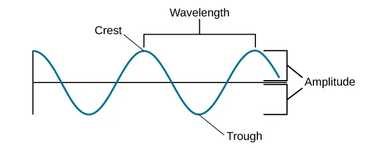

- **Question: Which of the following colored waves appears to have the longest wavelength?**
- A) Orange
- B) Yellow
- C) Green
- D) Dark red

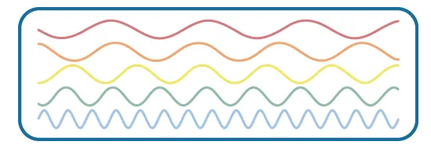

## 3.3 Light Waves

- We can’t see everything, but all of what we can see is called the **visible spectrum**
  - The visible spectrum sits within a larger **electromagnetic spectrum**, and is a relatively small portion, i.e., a lot more is invisible than visible

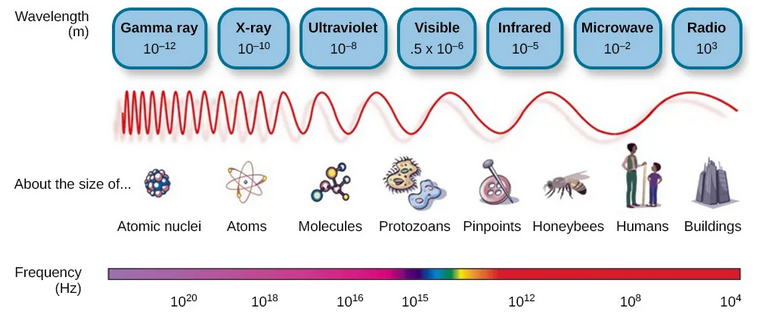

- Within that visible spectrum, we have our perception of color associated with different wavelengths

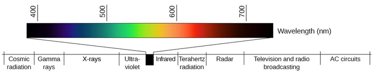

- Higher amplitude of light waves correspond to brighter light / more intense color

## 3.4 Sound Waves

- With sound, we often identify things by **pitch**: which is how “low” or “high” it sounds
  - A low pitch sound is associated with low-frequency
  - A high pitch sound is associated with high-frequency
- **Discuss: Based on the definitions of frequency and wavelength given before, would we expect the wavelength of high-frequency sounds to be relatively short or long? Explain.**
- Just like with the visible spectrum, we have an **audible spectrum**, outside which we cannot sense certain sounds
- In the case of audio, a higher amplitude of wave louder sound

# 4 Vision

Agenda

1 Overview and Introduction

2 Sensation versus Perception

3 Waves and Wavelengths

4 Vision

5 Hearing

6 The Other Senses

7 Conclusion

## 4.1 Introduction

- For most individuals, vision is the primary way we navigate and first interpret the world around us
  - Our specialized **eye** organ and associated structures allow us to sense, while our connected brain structures aid in perception

## 4.2 Anatomy of the Visual System

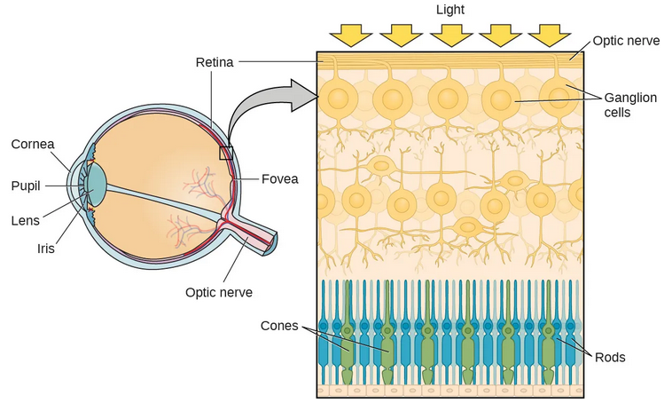

- The above image show the essential components of the human eye
- The structure and function of the eye parts are as follows:
  - **The cornea** is the outermost, transparent layer of the eye that both is a physical protective barrier and helps focus light
  - The **pupil** is the small opening (black hole) in our eye that can dilate or contract to let more or less light in
  - The pupil’s size is controlled by muscles in the **iris**, where we have color.
  - The **lens** within the pupil does even more focusing, hitting the **retina** on the back of the eye
  - The retina contains the **fovea**, contains specialized sensory neurons called **photoreceptor cells**
- Photoreceptor cells are one of two types:
  - **Cones** are mostly clustered in the fovea and help detect color, detail and dimension, but are especially light sensitive, i.e., don’t work well in the dark
  - **Rods** are throughout the retina and function better in low-light conditions to capture non-colored, non-detailed images
- **Important: This is why we can't see detail or color very well in the dark, because the cones aren't activated as much then, and we have to rely on our rods!**
- **Question: Review: The pupils normally dilates during periods of high arousal and alertness - what segment of the autonomic nervous system is active during times of high arousal?**
- A) Parasympathetic
- B) Central
- C) Peripheral
- D) Sympathetic

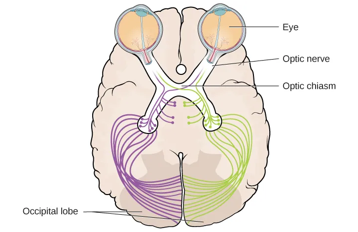

- Ganglion cells passed the signals from the photoreceptors back through the **optic nerve**. The placement of this optic nerve creates a natural **blind spot** in our vision
  - BUT, we don’t notice this because our two eyes have different, non-overlapping blindspots and our brain works to not perceive them
- Pay careful attention to which side of each eye goes to which side of the occipital lobe

## 4.3 Color Perception

- The most prominent theory and explanation for color vision follows the **trichromatic theory**
  - This states that all visible colors are a combination of red, green, and blue, resulting from 3 distinct cone types attuned to each of those colors
  - Evidence that this happens primarily on the retina

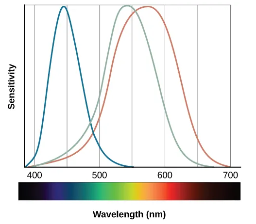

- Alternatively, there is **opponent-process theory** that suggest colors are perceived as one end of the pairs black-white, yellow-blue, and green-red.
  - Evidence that this happens on the optic nerve
- **Discuss: We call these theories - what does that mean and how does that differ from a hypothesis?**

## 4.4 Depth Perception

- **Depth perception** allows us to see in 3 dimensions, and see distances properly in space
- **Important: Without any proper depth perception, the world would look as flat as a painting!**
- We have two types of “clues” that allow for depth perception:
  - **Binocular cues** need both eyes
  - **Monocular cues** need only one eye
- In the case of binocular cues, we rely on things like **binocular disparity**, or the difference in sense between our eye
- For **monocular cues**, we can make sense of some depth even in a two-dimensional representation by looking at how things overlap or show relative size.

# 5 Hearing

Agenda

1 Overview and Introduction

2 Sensation versus Perception

3 Waves and Wavelengths

4 Vision

5 Hearing

6 The Other Senses

7 Conclusion

## 5.1 Introduction

- Much like the sense of **sight** comes from reception of light waves, the sense of hearing comes from reception of audio waves
- However, this process also involves air pressure, and a complex system of bones and membranes, just like the eye had several components

## 5.2 Anatomy of the Auditory System

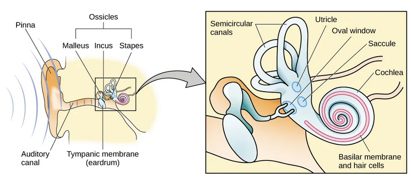

- Our ear has several important parts:
  - **Pinna**, the visible, protruding, wiggly part of our ear that focuses sound into..
  - The **auditory canal** which carries sound to the **tympanic membrane** which then transmits vibrations into…
  - Vital auditory organs including the three little bones of the **ossicles**
    - The **malleus (hammer)**, the **incus (anvil)**, and the **stapes (stirrup)**
- **Question: Review from above: what were the essential sensory cells of the visual system?**
- A) Photoreceptors
- B) Retina
- C) Pupil
- D) The optic nerve
- Past the initial pinna, tympanic membrane, and ossicles, there is the **cochlea**, which contains hair structures that function as the specialized sensory cells of the auditory system
  - The cochlea as a whole reminds me of a snail with the head of a cuttlefish
  - The stapes (last part of the ossicles) presses into the **oval window**, which in turn moves fluid around the **hair cells** embedded in the **basilar membrane** tissue in the cochlea
  - The mechanical movement of the hair causes the activation of neurons, firing their electrical impulses as a signal towards the brain
- **Discuss: What do we call the state when a neuron is 'ready' to fire? What characteristics are associated with that state?**
- **Question: Recall from biopsychology, which area of the cortex is most likely to recieve and process information about incoming auditory stimuli (hint, the one on the side of our heads!)**
- A) Occipital
- B) Parietal
- C) Frontal
- D) Temporal

## 5.3 Pitch Perception

- Earlier we discussed how different amplitudes and wavelengths are connected to the perception of high or low pitch. There are several theories that go further to explain this:
  - The **temporal theory** suggests that the speed of the firing of the hair cells determines the perceived frequency, but neurons can only fire so fast
- **Discuss: What is the period after an action potential in which a neuron cannot fire again for a short period of time?**
- **Place theory** instead suggests that hair cells on different parts of the basilar membrane are sensitive to different pitch sounds, an activation of a certain part of that membrane are responsible for perception of pitch
  - Under this theory, low-pitch sensors are towards the tip of the membrane, and high-pitch sensors are towards the base
- Both theories has decent evidence, suggesting they both likely hold some amount of truth

## 5.4 Sound Localization

- **Question: What did we call a visual cue that involves only one eye?**
- A) Binocular
- B) Monocular
- C) Triocular
- D) Basal
- In the auditory system, we have **monaural (one-ear)** and **binaural (two-ear)** cues that aid us primarily in locating sound
- The shape of our pinna, or external ear, plays a large role in helping us detect sound!
  - Monaural cues help us detect locate sounds on our midline axis: directly front, behind, above, and below us
  - Binaural cues consist of **interaural level difference**, or relative intensity of a sound to our ears, and **interaural timing difference**, when a sound wave reaches each of our ears; these cues help us on the horizontal access
- **Important: So our different cues for vision help us with depth, and our cues for audio help us with position.**

## 5.5 The Vestibular Sense, Proprioception, and Kinesthesia

- **Vestibular sense** is how we maintain balance and body posture, and is, surprisingly housed mostly in the inner ear
- **Question: Previously, we identified part of the hindbrain that has a lot to do with balance - which structure was that?**
- A) Suprachiasmatic Nucleus
- B) Broca's Area
- C) Thalamus
- D) Cerebellum
- Earlier we talk about the inner organ of the ear, but ignore several structures like the **utricle**, **saccule**, and the **semicircular canals**
  - These also have hair cells, just like the basilar membrane, but instead of being used for our awareness of sound, they are used to help us balance ourselves.
- These structures also contribute to **proprioception (perception of body position)** and **kinesthesia (perception of the body’s movement through space)** through those same hair like molecules

# 6 The Other Senses

Agenda

1 Overview and Introduction

2 Sensation versus Perception

3 Waves and Wavelengths

4 Vision

5 Hearing

6 The Other Senses

7 Conclusion

## 6.1 Introduction

- **Important: Vision and hearing are just two of our complex senses, we have many more! We'll pay less attention to them here, but you can dig in more in your book if you are interested!**
- While vision and audition both work on sensing of waves through different mechanisms, our senses have different processes to sense

## 6.2 The Chemical Senses

- Our senses of taste and smell both work by chemical receptors that are detected in food/drink and the air
  - They are also very interconnected

### Taste (Gustation)

- We have six taste groups:
  - Sweet
  - Salty
  - Sour
  - Bitter
  - Umami (Rough translation is “yummy”, connected to MSG)
  - Sense of fattiness in food
- This happens in the mouth, where **taste buds** on our tongue recieve information as our saliva breaks down food
  - Taste buds have a surprisingly short life span, which is why burning your tongue doesn’t have a permanent effect!

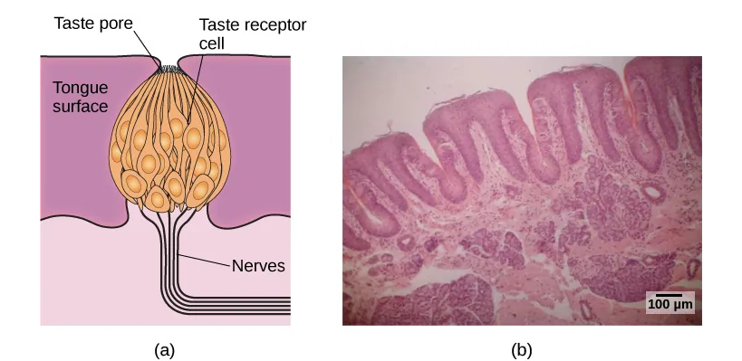

- Taste, after being routed through the thalamus, ends up being processed on the gustatory cortex, near the intersection of the frontal and temporal lobes

### Smell (Olfaction)

- Smell works on a similar principle to taste, where chemical odor molecules bind to sites on olfactory receptors, which in turn, sends signals to the **olfactory bulb**

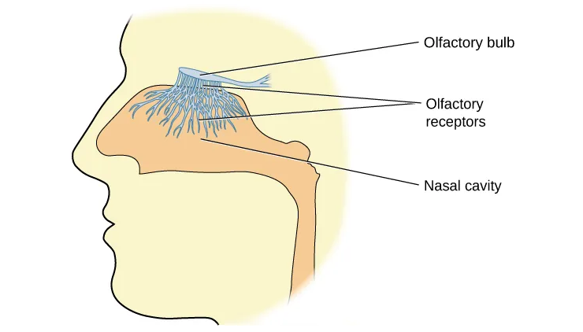

- Smell is processed on the **primary olfactory cortex**, near the gustatory cortex for taste processing
- **Important: This is one of many reasons that our sense of taste and smell are very related!**

## 6.3 Touch, Thermoception, and Nocicieption

- Our skin has many receptors to send signals related to different stimuli
  - **Meissner’s corpuscles** $\rightarrow$ pressure and lower frequency vibration
  - **Pacinian corpuscles** $\rightarrow$ high frequency vibration
  - **Merkel’s disks** $\rightarrow$ light pressure
  - **Ruffini corpuscles** $\rightarrow$ stretching sensation

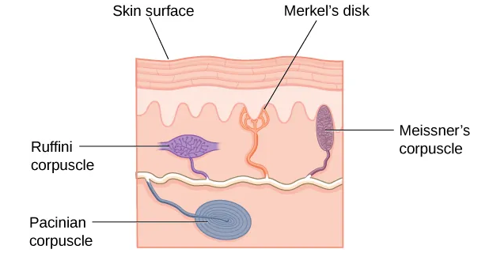

- Free nerve endings (those without specialized names) handle **thermoception (temperature)** and **nociception (harm/pain)**
- **Question: All of these skin and touch based signals are processed on the somatosensory cortex of which lobe?**
- A) Frontal
- B) Temporal
- C) Occipital
- D) Parietal

### Pain Perception

- **Important: Pain is not universally a 'bad' thing, it keeps us safe and helps us avoid further injury or damage to our body!**
- In general, there are two classification of pain:
  - **Inflammatory pain** comes from some type of tissue damage
  - **Neuropathic pain** comes from damage directly to the neurons of the CNS and/or PNS
- Treatment for pain can involve many techniques, including:
  - Talk therapy (pain psychology)
  - OTC or doctor-prescribed medications
  - Surgeries, device implants (deep-brain-stimulation)
  - Alternative methods: acupuncture, chiropractics, herbal remedies, etc.
- **Important: Treatment for pain can vary quite a bit across cultures, where some 'Western Medicine' places emphasis on use of medication, and others place value more in other methods of healing.**
- **Congenital analgesia (insensitivity to pain)** is a rare genetic condition that results in a reduced (or completely diminished) sense of pain.
- This is a very dangerous condition, as the body’s “warning system” is effectively not working properly

# 7 Conclusion

Agenda

1 Overview and Introduction

2 Sensation versus Perception

3 Waves and Wavelengths

4 Vision

5 Hearing

6 The Other Senses

7 Conclusion

## 7.1 Recap

- Our senses serve as the basic way that we recieve information about our world, and our sensory organs have complex structures and processes to aid in converting those stimuli into neuronal communications
- Biopsychology remains important, as our modern understanding of sensation is closely tied to brain structure and processing!
- Our perception is our integration and interpretation of sensory information, helpful in not just receiving, but understanding the external stimuli we encounter. Perception does not always contain all of the information transmitted by our senses, nor would we want it to!

## 7.2 Lecture Check-in

- Make sure to complete and submit the lecture check-in

[figure not shown]

Module 5 Lecture - Sensation and Perception || Introductory Psychology